# Sales Data Analysis Project

**Author**: MIKIYAS KIFLU **Date**: July 2025

## Project Overview

This project analyzes a real-world e-commerce dataset to uncover trends in sales performance. we aim to answer key business questions such as:

- What was the best month for sales?
- Which city had the highest number of sales?
- at what time are customers most likely to purchase?
- Which products sold the most and why?

we use Python libraries such as **Pandas**, **Matplotlib** to perform the analysis and create visual insigths.

## Importing Libraries

```python
import pandas as pd                      # Data manipulation and analysis
import matplotlib.pyplot as plt          # Data visualization (basic plotting)
import os                                # Interact with the operating system (e.g. file paths)
```

## Merge 12 months of sales data into one CSV

```python
# Read one month's file as example
df = pd.read_csv(r"C:\Users\user\Downloads\Task master\Pandas-Data-Science-Tasks-master\SalesAnalysis\Sales_Data\Sales_April_2019.csv")

# Get list of all monthly sales files
files = [file for file in os.listdir(r'C:\Users\user\Downloads\Task master\Pandas-Data-Science-Tasks-master\SalesAnalysis\Sales_Data')]

# Create empty DataFrame to store all data
all_months_data = pd.DataFrame()

# Concatenate each file into a single DataFrame
for  file in files:
    df = pd.read_csv(r'C:\Users\user\Downloads\Task master\Pandas-Data-Science-Tasks-master\SalesAnalysis\Sales_Data/'+file)
    all_months_data = pd.concat([all_months_data, df])

# Export combined data to CSV
all_months_data.to_csv("all_data.csv", index = False)
```

```python
# Load the combined sales data from the saved CSV file
all_data = pd.read_csv('all_data.csv')

# Display the first few rows to preview the data structure
all_data.head()
```

|  | Order ID | Product | Quantity Ordered | Price Each | Order Date | Purchase Address |
| --- | --- | --- | --- | --- | --- | --- |
| 0 | 176558 | USB-C Charging Cable | 2 | 11.95 | 04/19/19 08:46 | 917 1st St, Dallas, TX 75001 |
| 1 | NaN | NaN | NaN | NaN | NaN | NaN |
| 2 | 176559 | Bose SoundSport Headphones | 1 | 99.99 | 04/07/19 22:30 | 682 Chestnut St, Boston, MA 02215 |
| 3 | 176560 | Google Phone | 1 | 600 | 04/12/19 14:38 | 669 Spruce St, Los Angeles, CA 90001 |
| 4 | 176560 | Wired Headphones | 1 | 11.99 | 04/12/19 14:38 | 669 Spruce St, Los Angeles, CA 90001 |

## Cleaning the data

```python
# Check for missing values in each column of the dataset
all_data.isnull().sum()
```

```
Order ID            545
Product             545
Quantity Ordered    545
Price Each          545
Order Date          545
Purchase Address    545
dtype: int64
```

```python
# Check the data types of all columns in the dataset
all_data.dtypes
```

```
Order ID            object
Product             object
Quantity Ordered    object
Price Each          object
Order Date          object
Purchase Address    object
dtype: object
```

```python
# Parse 'Order Date' as datetime, set errors to NaT
all_data['Order Date'] = pd.to_datetime(
    all_data['Order Date'],
    format="%m/%d/%y %H:%M",
    errors='coerce'
)
```

```python
# Filter rows with any missing values
nan_df = all_data[all_data.isna().any(axis=1)]
nan_df.head()

# Drop rows that are entirely NaN
all_data = all_data.dropna(how='all')
all_data.head()
```

|  | Order ID | Product | Quantity Ordered | Price Each | Order Date | Purchase Address |
| --- | --- | --- | --- | --- | --- | --- |
| 0 | 176558 | USB-C Charging Cable | 2 | 11.95 | 2019-04-19 08:46:00 | 917 1st St, Dallas, TX 75001 |
| 2 | 176559 | Bose SoundSport Headphones | 1 | 99.99 | 2019-04-07 22:30:00 | 682 Chestnut St, Boston, MA 02215 |
| 3 | 176560 | Google Phone | 1 | 600 | 2019-04-12 14:38:00 | 669 Spruce St, Los Angeles, CA 90001 |
| 4 | 176560 | Wired Headphones | 1 | 11.99 | 2019-04-12 14:38:00 | 669 Spruce St, Los Angeles, CA 90001 |
| 5 | 176561 | Wired Headphones | 1 | 11.99 | 2019-04-30 09:27:00 | 333 8th St, Los Angeles, CA 90001 |

```python
# Check data types of key numeric columns
print(all_data[['Quantity Ordered', 'Price Each']].dtypes)
```

```
Quantity Ordered    object
Price Each          object
dtype: object
```

```python
# Ensure numeric types; invalid entries → NaN
all_data['Quantity Ordered'] = pd.to_numeric(all_data['Quantity Ordered'], errors='coerce')
all_data['Price Each'] = pd.to_numeric(all_data['Price Each'], errors='coerce')
```

```python
# Remove rows with NaNs in key numeric columns
all_data = all_data.dropna(subset=['Quantity Ordered', 'Price Each'])
```

```python
# Ensure numeric types for calculations
all_data['Quantity Ordered'] =  pd.to_numeric(all_data['Quantity Ordered'])
all_data['Price Each'] = pd.to_numeric(all_data['Price Each'])
```

## Exploratory Data Analysis

```python
# Calculate total sales per order
all_data['sales'] = all_data['Quantity Ordered'] * all_data['Price Each']
all_data.head()
```

|  | Order ID | Product | Quantity Ordered | Price Each | Order Date | Purchase Address | sales |
| --- | --- | --- | --- | --- | --- | --- | --- |
| 0 | 176558 | USB-C Charging Cable | 2.0 | 11.95 | 2019-04-19 08:46:00 | 917 1st St, Dallas, TX 75001 | 23.90 |
| 2 | 176559 | Bose SoundSport Headphones | 1.0 | 99.99 | 2019-04-07 22:30:00 | 682 Chestnut St, Boston, MA 02215 | 99.99 |
| 3 | 176560 | Google Phone | 1.0 | 600.00 | 2019-04-12 14:38:00 | 669 Spruce St, Los Angeles, CA 90001 | 600.00 |
| 4 | 176560 | Wired Headphones | 1.0 | 11.99 | 2019-04-12 14:38:00 | 669 Spruce St, Los Angeles, CA 90001 | 11.99 |
| 5 | 176561 | Wired Headphones | 1.0 | 11.99 | 2019-04-30 09:27:00 | 333 8th St, Los Angeles, CA 90001 | 11.99 |

```python
# Add 'Month' column for monthly analysis
all_data['Month'] = all_data['Order Date'].dt.month
all_data.head()
```

|  | Order ID | Product | Quantity Ordered | Price Each | Order Date | Purchase Address | sales | Month |
| --- | --- | --- | --- | --- | --- | --- | --- | --- |
| 0 | 176558 | USB-C Charging Cable | 2.0 | 11.95 | 2019-04-19 08:46:00 | 917 1st St, Dallas, TX 75001 | 23.90 | 4 |
| 2 | 176559 | Bose SoundSport Headphones | 1.0 | 99.99 | 2019-04-07 22:30:00 | 682 Chestnut St, Boston, MA 02215 | 99.99 | 4 |
| 3 | 176560 | Google Phone | 1.0 | 600.00 | 2019-04-12 14:38:00 | 669 Spruce St, Los Angeles, CA 90001 | 600.00 | 4 |
| 4 | 176560 | Wired Headphones | 1.0 | 11.99 | 2019-04-12 14:38:00 | 669 Spruce St, Los Angeles, CA 90001 | 11.99 | 4 |
| 5 | 176561 | Wired Headphones | 1.0 | 11.99 | 2019-04-30 09:27:00 | 333 8th St, Los Angeles, CA 90001 | 11.99 | 4 |

```python
# Extract city names from 'Purchase Address' by splitting the address string at commas
# The city is assumed to be the second element in the split list; strip removes extra spaces
all_data['City'] = all_data['Purchase Address'].apply(lambda x: x.split(',')[1].strip())

# Display the first few rows to verify the new 'City' column
all_data.head()
```

|  | Order ID | Product | Quantity Ordered | Price Each | Order Date | Purchase Address | sales | Month | City |
| --- | --- | --- | --- | --- | --- | --- | --- | --- | --- |
| 0 | 176558 | USB-C Charging Cable | 2.0 | 11.95 | 2019-04-19 08:46:00 | 917 1st St, Dallas, TX 75001 | 23.90 | 4 | Dallas |
| 2 | 176559 | Bose SoundSport Headphones | 1.0 | 99.99 | 2019-04-07 22:30:00 | 682 Chestnut St, Boston, MA 02215 | 99.99 | 4 | Boston |
| 3 | 176560 | Google Phone | 1.0 | 600.00 | 2019-04-12 14:38:00 | 669 Spruce St, Los Angeles, CA 90001 | 600.00 | 4 | Los Angeles |
| 4 | 176560 | Wired Headphones | 1.0 | 11.99 | 2019-04-12 14:38:00 | 669 Spruce St, Los Angeles, CA 90001 | 11.99 | 4 | Los Angeles |
| 5 | 176561 | Wired Headphones | 1.0 | 11.99 | 2019-04-30 09:27:00 | 333 8th St, Los Angeles, CA 90001 | 11.99 | 4 | Los Angeles |

### What was the beast month for sales? How much was earned that month?

```python
# Group data by 'Month' and calculate the sum for all numeric columns
# This aggregates monthly totals such as sales, quantity ordered, etc.
results = all_data.groupby('Month').sum(numeric_only=True)
```

### Sales by Month

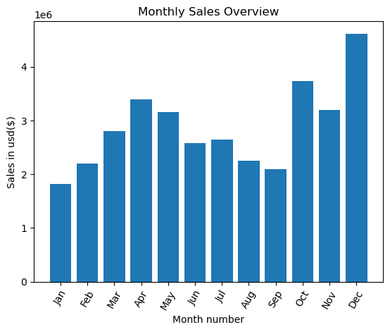

```python
import calendar

# Create a list of month numbers (1 to 12)
Months = range(1, 13)

# Generate abbreviated month names (Jan, Feb, ..., Dec) for x-axis labels
month_names = [calendar.month_abbr[i] for i in Months]

# Plot monthly total sales as a bar chart
plt.bar(Months, results['sales'])

# Customize x-axis ticks to show month abbreviations rotated for readability
plt.xticks(Months , month_names, rotation=60)

# Label x and y axes
plt.xlabel('Month number')
plt.ylabel('Sales in usd($)')

# Add a descriptive title to the plot
plt.title('Monthly Sales Overview')

# Display the plot
plt.show()
```

### What city had the highest number of sales?

```python
# Group data by 'City' and compute the sum for all numeric columns
# Aggregates total sales, quantity ordered, etc., per city
results = all_data.groupby('City').sum(numeric_only=True)

# Display the aggregated results
results
```

| City | Quantity Ordered | Price Each | sales | Month |
| --- | --- | --- | --- | --- |
| Atlanta | 16602.0 | 2779908.20 | 2795498.58 | 104794 |
| Austin | 11153.0 | 1809873.61 | 1819581.75 | 69829 |
| Boston | 22528.0 | 3637409.77 | 3661642.01 | 141112 |
| Dallas | 16730.0 | 2752627.82 | 2767975.40 | 104620 |
| Los Angeles | 33289.0 | 5421435.23 | 5452570.80 | 208325 |
| New York City | 27932.0 | 4635370.83 | 4664317.43 | 175741 |
| Portland | 14053.0 | 2307747.47 | 2320490.61 | 87765 |
| San Francisco | 50239.0 | 8211461.74 | 8262203.91 | 315520 |
| Seattle | 16553.0 | 2733296.01 | 2747755.48 | 104941 |

### Sales by City

[figure not shown]

```python
# Get the list of unique cities from the dataset
cities = all_data['City'].unique()

# Plot total sales per city as a bar chart
plt.bar(cities, results['sales'])

# Rotate city names on x-axis for better readability
plt.xticks(cities , rotation =60)

# Label x and y axes
plt.ylabel('Sales in USD($)')
plt.xlabel('Cities Name')

# Add a descriptive title to the plot
plt.title('Sales Performance Across Cities')

# Display the plot
plt.show()
```

### What time should we display advertisments to maxmize likelihood of customer's buying?

```python
# Extract the hour and minute components from 'Order Date' for time-based analysis
all_data['Hour'] = all_data['Order Date'].dt.hour
all_data['Minute'] = all_data['Order Date'].dt.minute
```

```python
# Display the first few rows of the DataFrame to inspect the data
all_data.head()
```

|  | Order ID | Product | Quantity Ordered | Price Each | Order Date | Purchase Address | sales | Month | City | Hour | Minute |
| --- | --- | --- | --- | --- | --- | --- | --- | --- | --- | --- | --- |
| 0 | 176558 | USB-C Charging Cable | 2.0 | 11.95 | 2019-04-19 08:46:00 | 917 1st St, Dallas, TX 75001 | 23.90 | 4 | Dallas | 8 | 46 |
| 2 | 176559 | Bose SoundSport Headphones | 1.0 | 99.99 | 2019-04-07 22:30:00 | 682 Chestnut St, Boston, MA 02215 | 99.99 | 4 | Boston | 22 | 30 |
| 3 | 176560 | Google Phone | 1.0 | 600.00 | 2019-04-12 14:38:00 | 669 Spruce St, Los Angeles, CA 90001 | 600.00 | 4 | Los Angeles | 14 | 38 |
| 4 | 176560 | Wired Headphones | 1.0 | 11.99 | 2019-04-12 14:38:00 | 669 Spruce St, Los Angeles, CA 90001 | 11.99 | 4 | Los Angeles | 14 | 38 |
| 5 | 176561 | Wired Headphones | 1.0 | 11.99 | 2019-04-30 09:27:00 | 333 8th St, Los Angeles, CA 90001 | 11.99 | 4 | Los Angeles | 9 | 27 |

### Orders by Hour

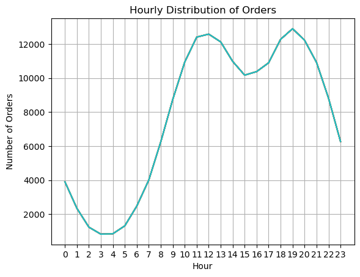

```python
# Extract the unique hours from the dataset by grouping on 'Hour'
hours = [hour for hour, df in all_data.groupby('Hour')]

# Plot the count of orders for each hour of the day
plt.plot(hours, all_data.groupby(['Hour']).count())

# Set x-axis ticks to show each hour
plt.xticks(hours)

# Add grid lines for better readability
plt.grid()

# Label x and y axes
plt.xlabel('Hour')
plt.ylabel('Number of Orders')

# Add a descriptive title to the plot
plt.title('Hourly Distribution of Orders')

# Display the plot
plt.show()
```

### What product sold the most?

### Most Sold Products

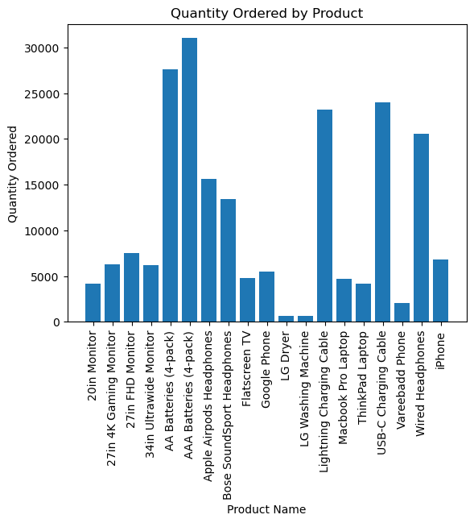

```python
# Group data by 'Product' to analyze sales per product
product_group = all_data.groupby('Product')

# Calculate total quantity ordered for each product
quantity_ordered = product_group.sum(numeric_only=True)['Quantity Ordered']

# Extract product names for plotting
products = [product for product, df in product_group]

# Create a bar chart showing quantityordered per product
plt.bar(products, quantity_ordered)

# Label x and y axes
plt.ylabel('Quantity Ordered')
plt.xlabel('Product Name')

# Add a descriptive title to the plot
plt.title('Quantity Ordered by Product')

# Rotate x-axis labels vertically for better readability
plt.xticks(products, rotation= 'vertical')

# Display the plot
plt.show()
```

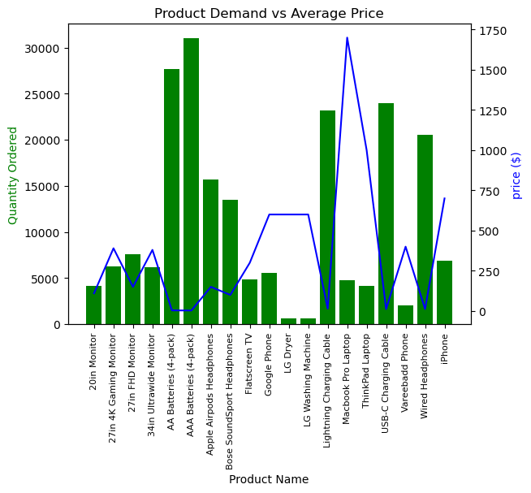

```python
# Calculate the average price for each product
prices = all_data.groupby('Product')['Price Each'].mean()

# Create a figure and primary axis for quantity ordered (bar chart)
fig, ax1 = plt.subplots()

# Create a secondary axis sharing the same x-axis for average price (line plot)
ax2 = ax1.twinx()

# Plot quantity ordered as green bars on the primary y-axis
ax1.bar(products, quantity_ordered, color='g')

# Plot average product price as a blue line on the secondary y-axis
ax2.plot(products, prices, 'b-')

# Label x-axis with product names
ax1.set_xlabel('Product Name')

# Label primary y-axis for quantity ordered, colored green to match bars
ax1.set_ylabel('Quantity Ordered', color='g')

# Label secondary y-axis for price, colored blue to match line plot
ax2.set_ylabel('price ($)', color='b')

# Set x-axis ticks and labels with vertical rotation for readability
positions = range(len(products))
ax1.set_xticks(positions)
ax1.set_xticklabels(products, rotation='vertical', size=8)

# Add a descriptive title comparing product demand to average price
plt.title('Product Demand vs Average Price')

# Display the plot
plt.show()
```

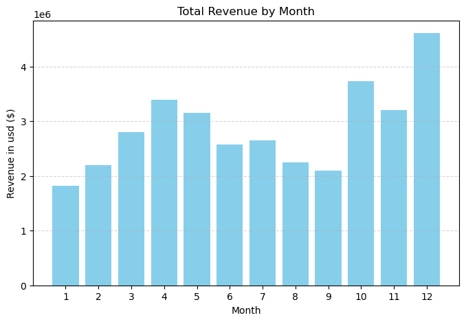

```python
# Group data by 'Month' and sum the total sales for each month
monthly_Sales = all_data.groupby('Month').sum(numeric_only=True)['sales']

# Extract month numbers to use as x-axis values
months = monthly_Sales.index.tolist()

# Create a bar chart with a specified figure size
plt.figure(figsize=(8,5))

# Plot total monthly revenue with sky blue bars
plt.bar(months, monthly_Sales, color='skyblue')

# Label x and y axes
plt.xlabel('Month')
plt.ylabel('Revenue in usd ($)')

# Add a descriptive title
plt.title('Total Revenue by Month')

# Set x-axis ticks to correspond to each month
plt.xticks(months)

# Add horizontal grid lines with subtle styling for better readability
plt.grid(axis='y', linestyle='--', alpha= 0.5)

# Show the plot
plt.show()
```

```python
# Group data by 'Product' to prepare for sales aggregation
product_sales = all_data.groupby('Product')
```

```python
# Display the first two rows of the DataFrame to preview the dataset
all_data.head(2)
```

|  | Order ID | Product | Quantity Ordered | Price Each | Order Date | Purchase Address | sales | Month | City | Hour | Minute |
| --- | --- | --- | --- | --- | --- | --- | --- | --- | --- | --- | --- |
| 0 | 176558 | USB-C Charging Cable | 2.0 | 11.95 | 2019-04-19 08:46:00 | 917 1st St, Dallas, TX 75001 | 23.90 | 4 | Dallas | 8 | 46 |
| 2 | 176559 | Bose SoundSport Headphones | 1.0 | 99.99 | 2019-04-07 22:30:00 | 682 Chestnut St, Boston, MA 02215 | 99.99 | 4 | Boston | 22 | 30 |

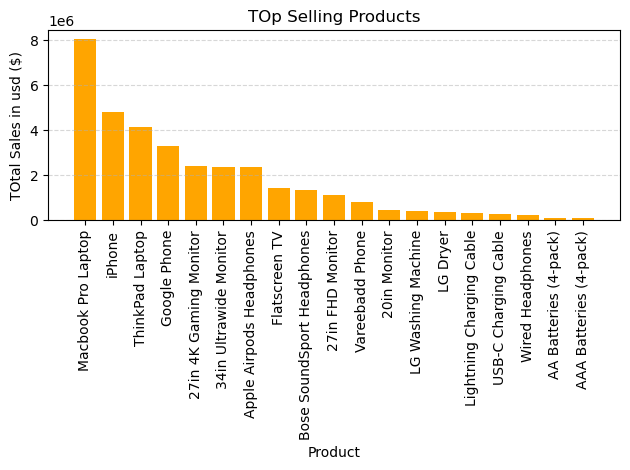

```python
# Aggregate total sales by product by grouping and summing sales
product_sales = all_data.groupby('Product').sum(numeric_only=True)['sales']

# Sort products by total sales in descending order to identify top sellers
product_sales_sorted = product_sales.sort_values(ascending=False)

# Plot a vertical bar chart of total sales per product with orange bars
plt.bar(product_sales_sorted.index, product_sales_sorted.values, color='orange')

# Rotate x-axis labels vertically for readability
plt.xticks(rotation='vertical')

# Label the axes
plt.xlabel('Product')
plt.ylabel('TOtal Sales in usd ($)')

# Add a descriptive title to highlight top selling products
plt.title('TOp Selling Products')

# Add subtle horizontal grid lines for better visual guidance
plt.grid(axis='y', linestyle='--', alpha=0.5)

# Adjust layout to prevent label overlap
plt.tight_layout()

# Display the plot
plt.show()
```

```python
# Calculate the total revenue across all orders
total_revenue = all_data['sales'].sum()

# Count the total number of orders (rows in the dataset)
total_orders = len(all_data)

# Compute the average order value (total revenue divided by number of orders)
average_order_value = total_revenue /  total_orders

# Display the average order value formatted to two decimal places
f"Average Order Value: ${average_order_value:.2f}"
```

```
'Average Order Value: $185.49'
```

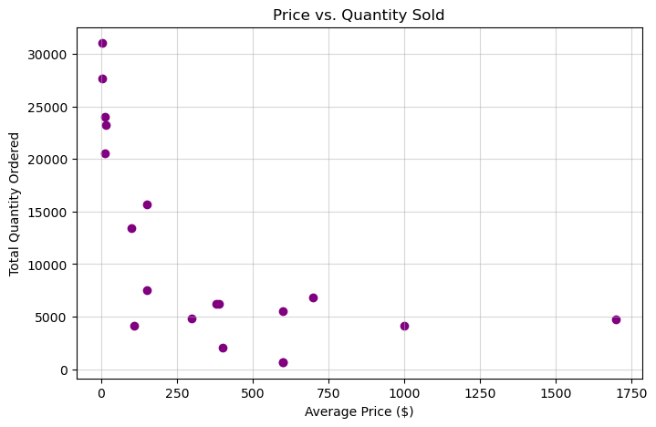

```
'Correlation between price and quantity sold: -0.60'
```

```python
# Calculate the average price for each product
avg_price = all_data.groupby('Product')['Price Each'].mean()

# Calculate the total quantity ordered for each product
quantity_ordred = all_data.groupby('Product')['Quantity Ordered'].sum()

# Create a scatter plot to visualize the relationship between average price and quantity sold
plt.figure(figsize=(8,5))
plt.scatter(avg_price, quantity_ordered, color='purple')

# Label the axes
plt.xlabel('Average Price ($)')
plt.ylabel('Total Quantity Ordered')

# Add a descriptive title to the plot
plt.title('Price vs. Quantity Sold')

# Add grid lines for readability
plt.grid(alpha=0.5)

# Display the scatter plot
plt.show()

# Calculate the correlation coefficient between average price and quantity sold
correlation = avg_price.corr(quantity_ordered)

# Display the correlation value formatted to two decimal places
f"Correlation between price and quantity sold: {correlation:.2f}"
```

```python
# Save the current figure as a PNG image file with tight bounding box to avoid clipping labels
plt.savefig("product_sales.png", bbox_inches='tight')
```

```python
all_data.head(2)
```

|  | Order ID | Product | Quantity Ordered | Price Each | Order Date | Purchase Address | sales | Month | City | Hour | Minute |
| --- | --- | --- | --- | --- | --- | --- | --- | --- | --- | --- | --- |
| 0 | 176558 | USB-C Charging Cable | 2.0 | 11.95 | 2019-04-19 08:46:00 | 917 1st St, Dallas, TX 75001 | 23.90 | 4 | Dallas | 8 | 46 |
| 2 | 176559 | Bose SoundSport Headphones | 1.0 | 99.99 | 2019-04-07 22:30:00 | 682 Chestnut St, Boston, MA 02215 | 99.99 | 4 | Boston | 22 | 30 |

## Conclusion

These insights can guide better inventory and advertising strategies.